# Project 1 Happyness Moment

HappyDB is a corpus of 100,000 crowd-sourced happy moments via Amazon’s Mechanical Turk. You can read more about it on https://arxiv.org/abs/1801.07746. Here we will dig deeper about the words of Happy Moment Sentences and visualize some detail aspects related with happiness.

In this bolg, we will first overview what the happy moments are about and then zoom in the small group of people, parents. The main interest of this bolg is to find the sources of happy moments for parents. To dig deeper, we want to find the differences in happy topics for mathers and fathers.

### Step 0 - Load the required R Packages

```r
packages.used = c("tidytext", "tidyverse", "DT", "scales", "wordcloud2", "gplots",
    "sentimentr", "ngram", "dplyr", "qdap", "ggplot2", "topicmodels", "slam",
    "shiny")

# check packages that need to be installed.
packages.needed = setdiff(packages.used, intersect(installed.packages()[, 1],
    packages.used))
# install additional packages
if (length(packages.needed) > 0) {
    install.packages(packages.needed, dependencies = TRUE)
}

library(tidyverse)
library(tidytext)
library(DT)
library(scales)
library(wordcloud2)
library(gridExtra)
library(ngram)
library(shiny)
library(topicmodels)
library(tm)
library(ggplot2)
library(dplyr)
library(slam)
```

### Step 1 - Data Preparation and Overview

We will use the data in `processed_moments.csv` that has already been stemmed and filtered out stop words. And we join the processedd text data with the demographic data, which will be futher analized in following steps.

```r
hm_data <- read_csv("../output/processed_moments.csv")
demo_link <- "https://raw.githubusercontent.com/rit-public/HappyDB/master/happydb/data/demographic.csv"
demo_data <- read_csv(demo_link)
```

```r
hm_data <- hm_data %>% inner_join(demo_data, by = "wid") %>% select(wid, original_hm,
    num_sentence, gender, marital, parenthood, reflection_period, age, country,
    ground_truth_category, predicted_category, text) %>% mutate(count = sapply(hm_data$text,
    wordcount))
```

Here we can firstly overviw the top 200 frequent words about happy moments using word cloud. Overall, the top three frequentest words related happy moment are *friend*, *time*, *day*. It may reveal that we, social creatures, are more likely to experience happy moment staying, talking, palying, working et.al with our friends fro some day, some time in some place.

According to the `predicted_category` which classify happy moments into different types, the two main categories are *affection* and *achievement*. It means happiness mainly stem from spiritual satisfaction and self-fulfillment.

```r
bag_of_words <- hm_data %>% unnest_tokens(word, text)

word_count <- bag_of_words %>% count(word, sort = TRUE)

wordcloud2(data = word_count[1:200, ])
```

[interactive chart not shown]

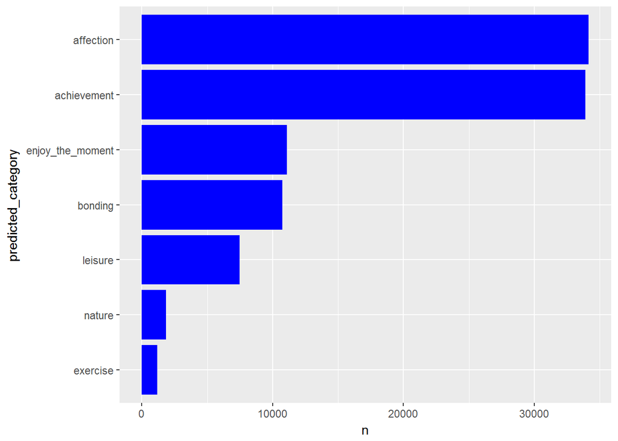

```r
word_count_cat <- hm_data %>% count(predicted_category, sort = TRUE)
ggplot(data = word_count_cat, aes(x = reorder(predicted_category, n), y = n)) +
    geom_bar(stat = "identity", fill = "blue") + xlab("predicted_category") +
    coord_flip()
```